# Richness in IBC_grass.noNDD

This document describes IBC_grass.noNDD, using **Richness** as the focal biodiversity metric.

# 1 Initial inspection

The raw data:

```r
IBC_grass.noNDD$data %>%
    as.data.frame() %>%
    head(10) %>%
    kable()
```

| Ninitial | Rep | SeedRain | Stage | Year | FDis | total.biomass | Shannon | Richness |
| --- | --- | --- | --- | --- | --- | --- | --- | --- |
| 64 | 385 | 100 | metacommunity | 100 | 1.2083803 | 99.33201 | 1.716179 | 27 |
| 64 | 385 | 100 | isolation | 200 | 1.1449454 | 99.28402 | 1.364086 | 2 |
| 32 | 376 | 100 | metacommunity | 100 | 1.5762534 | 53.11400 | 2.064792 | 25 |
| 32 | 376 | 100 | isolation | 200 | 2.1105334 | 54.22630 | 1.888920 | 3 |
| 16 | 286 | 100 | metacommunity | 100 | 0.0309334 | 99.45081 | 1.032366 | 10 |
| 16 | 286 | 100 | isolation | 200 | 0.0000000 | 99.49639 | 1.000000 | 1 |
| 16 | 285 | 100 | metacommunity | 100 | 0.3340393 | 54.80066 | 1.289209 | 14 |
| 16 | 285 | 100 | isolation | 200 | 0.0000000 | 54.72242 | 1.000000 | 1 |
| 16 | 284 | 100 | metacommunity | 100 | 0.2928176 | 52.53686 | 1.295292 | 15 |
| 16 | 284 | 100 | isolation | 200 | 0.0000000 | 52.23278 | 1.000000 | 1 |

Plotted without fits:

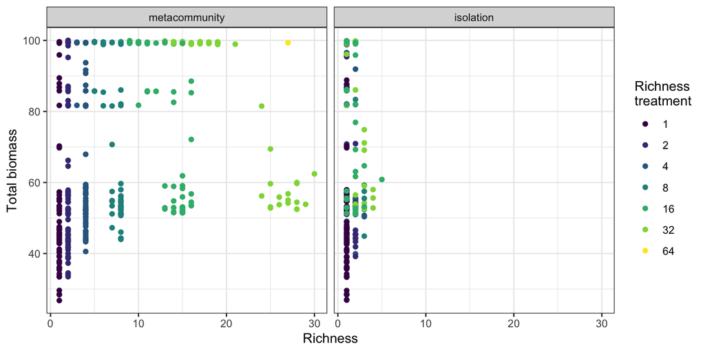

```r
ggplot(IBC_grass.noNDD %>% unnest(data)) +
    geom_point(aes(x = Richness,
                   y = total.biomass,
                   color = as.factor(Ninitial))) +
    facet_grid(. ~ Stage) +
    labs(x = "Richness",
         y = "Total biomass",
         color = "Richness\ntreatment") +
    scale_color_viridis(discrete = TRUE) +
    theme_bw()
```

# 2 Fitting the model

## 2.1 Main effect

The main effect represents the relationship between diversity and total biomass without taking into account the richness treatment.

To produce this model, we use the call:

```r
brm(formula = total.biomass ~ -1 + Stage + Stage:Richness,
    data = IBC_grass.noNDD)
```

A summary table of the result:

```r
IBC_grass.noNDD$mainEffect[[1]]
```

```
##  Family: gaussian
##   Links: mu = identity; sigma = identity
## Formula: total.biomass ~ -1 + Stage + Stage:Richness
##    Data: d_ (Number of observations: 770)
## Samples: 4 chains, each with iter = 2000; warmup = 1000; thin = 1;
##          total post-warmup samples = 4000
##
## Population-Level Effects:
##                             Estimate Est.Error l-95% CI u-95% CI Rhat Bulk_ESS Tail_ESS
## Stagemetacommunity             60.05      1.76    56.69    63.51 1.00     3048     2252
## Stageisolation                 72.01      2.74    66.75    77.41 1.00     2659     2474
## Stagemetacommunity:Richness     1.09      0.17     0.76     1.42 1.00     2832     2472
## Stageisolation:Richness        -2.32      1.86    -6.05     1.28 1.00     2651     2555
##
## Family Specific Parameters:
##       Estimate Est.Error l-95% CI u-95% CI Rhat Bulk_ESS Tail_ESS
## sigma    22.89      0.58    21.81    24.09 1.00     3311     2739
##
## Samples were drawn using sampling(NUTS). For each parameter, Bulk_ESS
## and Tail_ESS are effective sample size measures, and Rhat is the potential
## scale reduction factor on split chains (at convergence, Rhat = 1).
```

> Note the `Rhat` summary column: variation from 1.0 indicates the the model did not converge.

The R-squared:

```r
rstantools::bayes_R2(IBC_grass.noNDD$mainEffect[[1]])
```

```
##      Estimate  Est.Error       Q2.5      Q97.5
## R2 0.05745647 0.01542032 0.02933874 0.08943287
```

### 2.1.1 Posterior predictive checks

We next use posterior predictive checks (PPC) to judge the fit of the model. These compare the real data to the posterior distribution, conditioned on the observed data.

The density of both the real data (`y`, black line), and from fitted draws of the models (`y_rep`, blue lines).

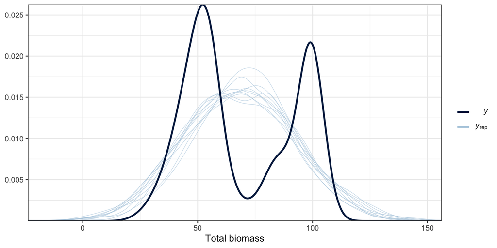

```r
brms::pp_check(IBC_grass.noNDD$mainEffect[[1]]) +
    labs(x = "Total biomass") +
    theme_bw()
```

The second PPC for the main effect is the average prediction (`y_rep`) for each real datapoint (`y`). A line indicates a 1:1 correspondence for reference.

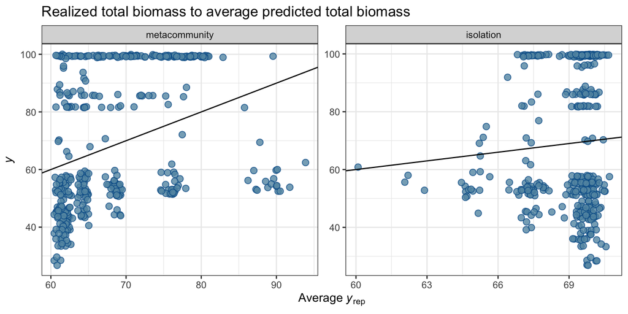

```r
brms::pp_check(IBC_grass.noNDD$mainEffect[[1]],
               type = 'scatter_avg_grouped',
               group = "Stage") +
    geom_abline(intercept = 0,
                slope = 1) +
    labs(title = "Realized total biomass to average predicted total biomass") +
    theme_bw()
```

Lastly, we inspect the highest-density interval (HDI) for each effect within the model. This characterizes the uncertainty of our posterior distributions. Highest-density intervals can be thought of as credibility intervals. A nice graphic explaining them can be found [here](https://mathematica.stackexchange.com/questions/173282/computing-credible-region-highest-posterior-density-from-empirical-distributio). I use the 89% HDI as recommended by Kruschke (2014), see [here](https://easystats.github.io/bayestestR/reference/hdi.html).

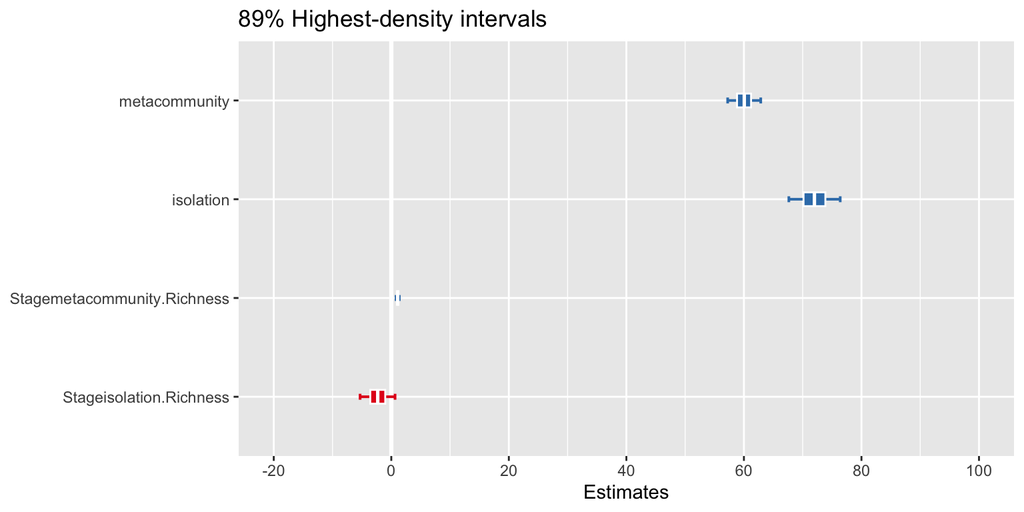

```r
sjPlot::plot_model(IBC_grass.noNDD$mainEffect[[1]],
                   title = "89% Highest-density intervals")
```

## 2.2 Treatment effects

For the treatment effect we incorporate the different richness treatments into the model, giving each combination a different intercept and slope.

We use the formula:

```r
brm(formula = total.biomass ~ -1 + Ninitial:Stage + Ninitial:Stage:Richness,
    data = IBC_grass.noNDD)
```

Note that both `Ninitial` and `Stage` are treated as categorical variables. Further, because both the monocultures and the singleton 64-species community have no variation with respect to realized diversity, they are omitted from this model.

The summary table:

```r
IBC_grass.noNDD$treatmentEffect[[1]]
```

```
##  Family: gaussian
##   Links: mu = identity; sigma = identity
## Formula: total.biomass ~ -1 + Ninitial:Stage + Ninitial:Stage:Richness
##    Data: d_ (Number of observations: 640)
## Samples: 4 chains, each with iter = 2000; warmup = 1000; thin = 1;
##          total post-warmup samples = 4000
##
## Population-Level Effects:
##                                        Estimate Est.Error l-95% CI u-95% CI Rhat Bulk_ESS Tail_ESS
## Ninitial2:Stagemetacommunity             140.65     24.51    92.42   188.84 1.00     4077     2939
## Ninitial4:Stagemetacommunity             148.12     16.19   117.17   180.11 1.00     3541     2646
## Ninitial8:Stagemetacommunity             154.72     11.65   130.96   177.50 1.00     3747     3027
## Ninitial16:Stagemetacommunity            160.45     11.40   138.74   183.53 1.00     3585     2776
## Ninitial32:Stagemetacommunity            155.90      8.60   139.48   173.30 1.00     3796     2881
## Ninitial2:Stageisolation                  74.42      6.46    61.92    87.26 1.00     4065     2431
## Ninitial4:Stageisolation                  74.83      5.68    63.76    85.91 1.00     3557     2868
## Ninitial8:Stageisolation                  82.37      5.28    72.00    92.71 1.00     3734     3451
## Ninitial16:Stageisolation                 92.59      4.60    83.84   101.65 1.00     3537     3165
## Ninitial32:Stageisolation                115.35      4.86   105.86   124.89 1.00     3899     3110
## Ninitial2:Stagemetacommunity:Richness    -41.35     12.40   -65.73   -16.96 1.00     4062     3137
## Ninitial4:Stagemetacommunity:Richness    -22.17      4.20   -30.42   -14.00 1.00     3569     2631
## Ninitial8:Stagemetacommunity:Richness    -12.02      1.64   -15.17    -8.76 1.00     3806     3039
## Ninitial16:Stagemetacommunity:Richness    -6.46      0.88    -8.20    -4.76 1.00     3555     2721
## Ninitial32:Stagemetacommunity:Richness    -3.52      0.43    -4.39    -2.70 1.00     3851     2732
## Ninitial2:Stageisolation:Richness        -13.03      5.10   -23.04    -2.90 1.00     3996     2741
## Ninitial4:Stageisolation:Richness         -9.14      4.27   -17.76    -0.86 1.00     3301     2935
## Ninitial8:Stageisolation:Richness         -8.63      3.53   -15.42    -1.69 1.00     3663     3423
## Ninitial16:Stageisolation:Richness        -9.13      2.76   -14.54    -3.92 1.00     3607     3028
## Ninitial32:Stageisolation:Richness       -14.88      2.53   -19.87    -9.92 1.00     4032     2961
##
## Family Specific Parameters:
##       Estimate Est.Error l-95% CI u-95% CI Rhat Bulk_ESS Tail_ESS
## sigma    16.99      0.49    16.08    18.00 1.00     5988     3075
##
## Samples were drawn using sampling(NUTS). For each parameter, Bulk_ESS
## and Tail_ESS are effective sample size measures, and Rhat is the potential
## scale reduction factor on split chains (at convergence, Rhat = 1).
```

We now see that there is an intercept for each combination of `Ninitial` and `Stage`, and a slope that describes this this combination with reference to `Richness`.

> Note the `Rhat` summary column: variation from 1.0 indicates the the model did not converge.

The R-squared:

```r
rstantools::bayes_R2(IBC_grass.noNDD$treatmentEffect[[1]])
```

```
##     Estimate Est.Error      Q2.5     Q97.5
## R2 0.4625726 0.0208924 0.4190142 0.5014695
```

### 2.2.1 Posterior predictive checks

As before, initially we compare the distribution of the real data (`y`, black line) to simulated distributions output from our model (`y_rep`, blue lines).

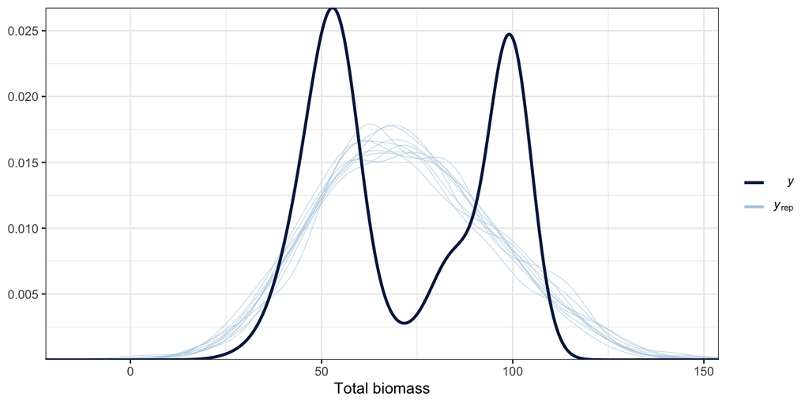

```r
brms::pp_check(IBC_grass.noNDD$treatmentEffect[[1]]) +
    labs(x = "Total biomass") +
    theme_bw()
```

And now a scatter plot of the simulated data in relation to the real data, grouping the comparison of `y` to `y_rep` by `Ninitial`.

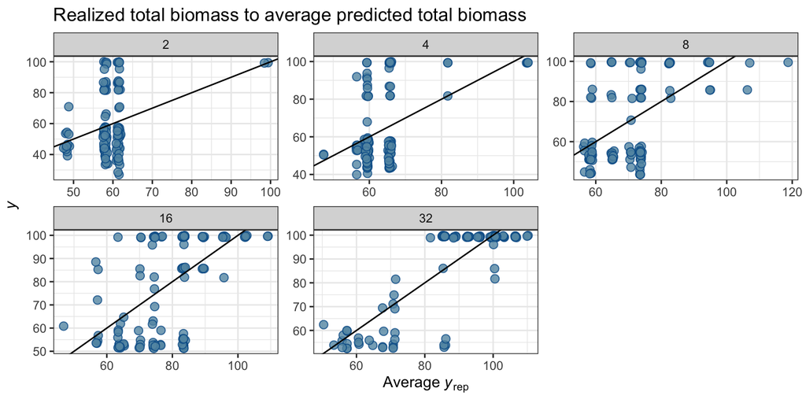

```r
brms::pp_check(IBC_grass.noNDD$treatmentEffect[[1]],
               type = 'scatter_avg_grouped',
               group = "Ninitial") +
    geom_abline(intercept = 0,
                slope = 1) +
    labs(title = "Realized total biomass to average predicted total biomass") +
    theme_bw()
```

The 89% highest-density interval (HDI):

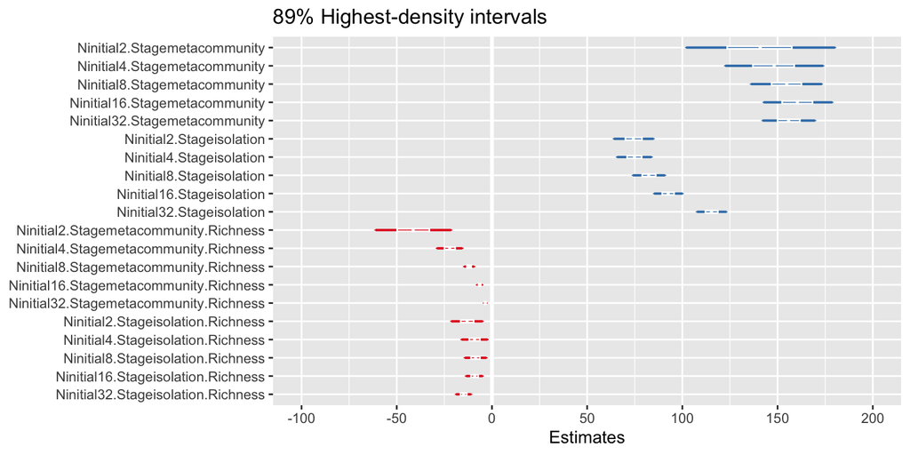

```r
sjPlot::plot_model(IBC_grass.noNDD$treatmentEffect[[1]],
                   title = "89% Highest-density intervals")
```

# 3 Plotting the final model fits

And now I plot the final fits:

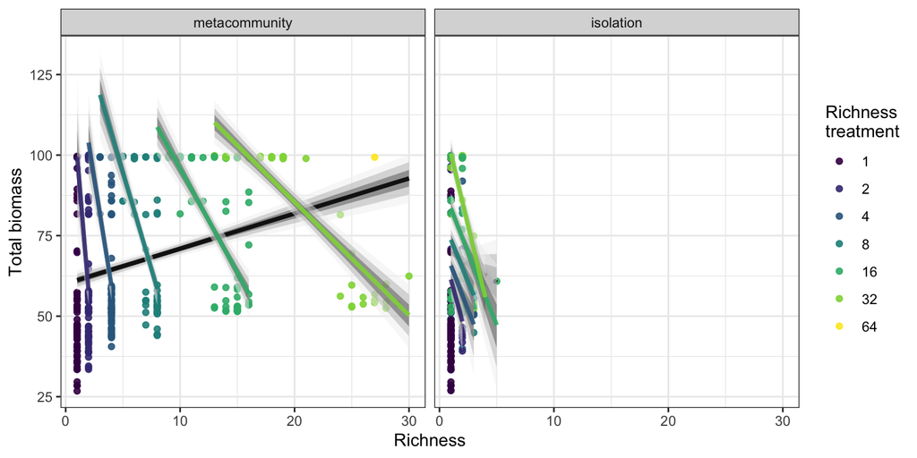

```r
extract_significances_mainEffect <- function(model_, measure_)
{
    hdi_ <- bayestestR::hdi(model_) %>%
        mutate(significant = !(0 >= CI_low & 0 <= CI_high))

    hdi_ <- hdi_ %>%
        filter(str_detect(Parameter, measure_)) %>%
        mutate(Stage = ifelse(str_detect(Parameter, "metacommunity"),
                              "metacommunity",
                              "isolation"))

    hdi_ <- hdi_ %>%
        mutate(Stage = as.factor(Stage)) %>%
        select(Stage, significant)

  hdi_ <- hdi_ %>%
    mutate(Stage = fct_relevel(Stage, c("metacommunity", "isolation")))

    return(hdi_)
}

extract_significances_treatmentEffect <- function(model_, measure_)
{
    hdi_ <- bayestestR::hdi(model_) %>%
        mutate(significant = !(0 >= CI_low & 0 <= CI_high))

    hdi_ <- hdi_ %>%
        filter(str_detect(Parameter, measure_)) %>%
        mutate(Stage = ifelse(str_detect(Parameter, "metacommunity"),
                              "metacommunity",
                              "isolation")) %>%
        mutate(Ninitial = str_extract(Parameter, "\\d+"))

    hdi_ <- hdi_ %>%
        mutate(Stage = as.factor(Stage),
               Ninitial = as.factor(Ninitial)) %>%
        select(Stage, Ninitial, significant)

  hdi_ <- hdi_ %>%
    mutate(Stage = fct_relevel(Stage, c("metacommunity", "isolation")))

    return(hdi_)
}

data <- IBC_grass.noNDD %>% unnest(data)
mainEffect_ <- IBC_grass.noNDD$mainEffect[[1]]
treatmentEffect_ <- IBC_grass.noNDD$treatmentEffect[[1]]

mainEffect <- data %>%
    group_by(Stage) %>%
    data_grid(Richness) %>%
    add_fitted_draws(mainEffect_) %>%
    inner_join(extract_significances_mainEffect(mainEffect_, "Richness"))

treatmentEffect <- data %>%
    filter(Ninitial %in% levels(treatmentEffect_$data$Ninitial)) %>%
    droplevels() %>%
    group_by(Ninitial, Stage) %>%
    data_grid(Richness) %>%
    add_fitted_draws(treatmentEffect_) %>%
    inner_join(extract_significances_treatmentEffect(treatmentEffect_, "Richness"))

ggplot() +
    geom_point(data = data,
               aes(x = Richness,
                   y = total.biomass,
                   color = Ninitial),
               alpha = 0.9) +
    stat_lineribbon(data = mainEffect,
                    aes(x = Richness,
                        y = .value,
                        group = Stage,
                        linetype = significant),
                    alpha = 0.5,
                    show.legend = FALSE) +
    stat_lineribbon(data = treatmentEffect,
                    aes(x = Richness,
                        y = .value,
                        color = Ninitial,
                        group = Ninitial,
                        linetype = significant),
                    alpha = 0.5,
                    show.legend = FALSE) +
    scale_linetype_manual(values = c("twodash", "solid")) +
    facet_grid(. ~ Stage) +
    labs(x = "Richness",
         y = "Total biomass",
         color = "Richness\ntreatment") +
    scale_color_viridis(discrete = TRUE) +
    scale_fill_brewer(palette = "Greys") +
    theme_bw()
```

Ribbons indicate 95%, 80%, and 50% credibility intervals. The black line represents the main effect, omitting the richness treatments. Dashed lines have estimates that include 0 within their 89% HDI.